# Demonstration of bias caused by double dipping in ERP research

DVM Bishop

2nd July 2018

## Demonstration 1: peak-picking

Peak-picking is when a waveform is scrutinised for a peak, and the peak value is used in an analysis. This is a particular (and well-known) problem if the goal is to demonstrate that the component is present, i.e. if the peak values are then compared statistically to zero. It virtually guarantees a significant result on one-sample t-test, because any noise that pushes the signal in one direction is included with the true signal.

This is best illustrated with the situation when there is no signal - the waveform is just flat.

You can’t simulate ERPs just as a set of random numbers, because for a realistic waveform you need autocorrelation - i.e. each datapoint depends on the previous datapoint. The higher the autocorrelation, the smoother the waveform will be. In my experience, ERP waveforms typically have autocorrelation values of .8 or more - though this depends on the sampling rate. The higher the sampling rate, the closer together the points, and the higher the autocorrelation.

Here I use a very simple approach to simulating a waveform. The series starts with zero, and then for each subsequent datapoint I generate a random number (a normal deviate, which can be positive or negative). The simulated data is then a weighted sum of the previous datapoint and the random number. The two weights sum to one, so in effect, if you want a noisier waveform you just decrease the weight for the previous datapoint.

The simulation is complicated by the fact that I want to allow for the possibility that there will be part of the waveform where there is a real effect. I’m simulating the difference wave called mismatch negativity, so when there is a real effect, there will be a dip down in the signal. To include this, I first specify 3 phases: for the first and last phase, the true signal is a straight line, for the middle phase, there is a MMN. Then for simulating datapoints in the middle phase, the true signal is added to the weighted sum. We multiply the true signal effect by a weight that will determine how big the impact of the true signal is relative to background noise. If we want to simulate the situation with no true effect, we can just set that weight to zero.

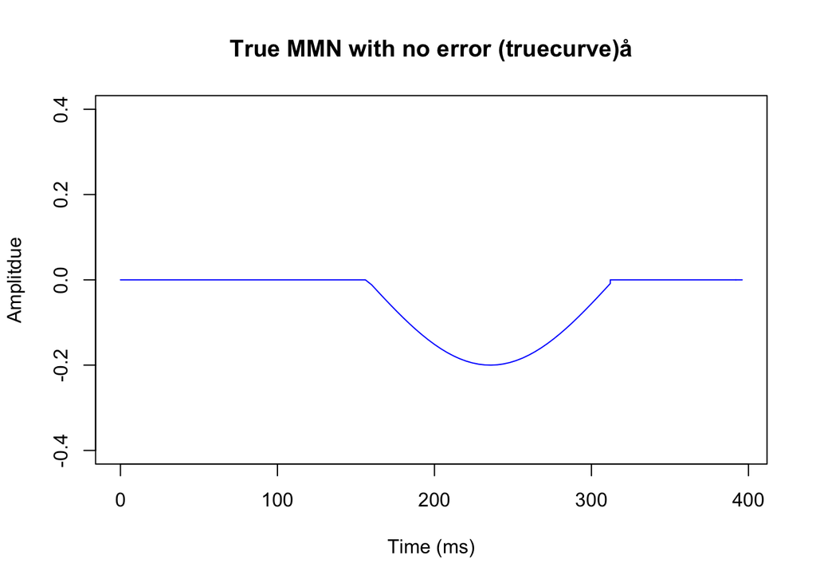

```r
#Simplified waveform: baseline is flat, then downward blip then flat again
pngplot <- 0 #if you toggle this value to 1, graphs will be created as png rather than on screen

myt <- seq(0,400,4) #vector of times for the epoch; 0 to 400 in steps of 4 ms

phase1t <-c(0,160) #time range for phase 1 - flat signal
phase1r<-which(myt<phase1t[2]) #r gives range of indices of time vector for this phase
phase1v <-rep(0,length(phase1r)) #v gives amplitudes for true signal in this phase - all zero

phase2t <-c(161,316) #time range for phase with U function
w3<-max(which(myt<phase2t[1]))
w4<-max(which(myt<phase2t[2]))
phase2r <- w3:w4 #r gives range of indices of time vector for phase 2
phase2v <- sin(myt[phase2r]/50)/5 #amplitudes for phase 2: should be possible to do this in a
#more elegant way: these values are just hand-crafted so that for these timings we get a nice U-function

phase3t <-c(316,400) #back to flat line after the U-function
w5<-max(which(myt<phase3t[1]))
w6<-max(which(myt<phase3t[2]))
phase3r <-w5:w6
phase3v <-rep(0,length(w5:w6))

#Now create x and y vectors for plotting
alltime <-myt[c(phase1r,phase2r,phase3r)]
truecurve <- c(phase1v,phase2v,phase3v)

if(pngplot==1){
  png("trueMMN.png",width = 4, height = 4, units = 'in', res = 300)
}
plot(alltime,truecurve,type='n',ylim=c(-.4,.4),main='True MMN with no error (truecurve)å',
     ylab = 'Amplitdue',xlab='Time (ms)') #create frame to plot lines in
lines(alltime,truecurve,col='blue') #add the lines
```

```r
if(pngplot==1){
  dev.off() #turn off printing to png
}
```

Now we make a function that generates simulated waveforms based on this true function (truecurve). Each datapoint is generated as a weighted sum of: * The previous datapoint * Random noise * The true curve

Two weights are specified: wt1 is used for previous datapoint, and (1-wt1) is weighting for the random noise. These sum to 1. wt2 is weighting for true curve: if this is zero, then we have a flat line; if it is high, then we see the effect of the true curve clearly.

The next chunk of code defines the function for generating this. This does not generate any output but it is used by other code chunks.

```r
mymakewave <- function(timepts,wt1,wt2,truecurve) {
  mywavevec<-rep(0,timepts) #start at zero
  for (j in 2:timepts){

    #work out next timepoint on basis of previous timepoint, randomness plus true curve
    mywavevec[j]<-wt1*mywavevec[j-1]+(1-wt1)*rnorm(1)+wt2*truecurve[j]
  }
  return(mywavevec)
}
```

This next chunk of code can be run to test how mymakewave works. N.B. If you want to run testmakewave, you need first to run the previous makewave definition chunk.

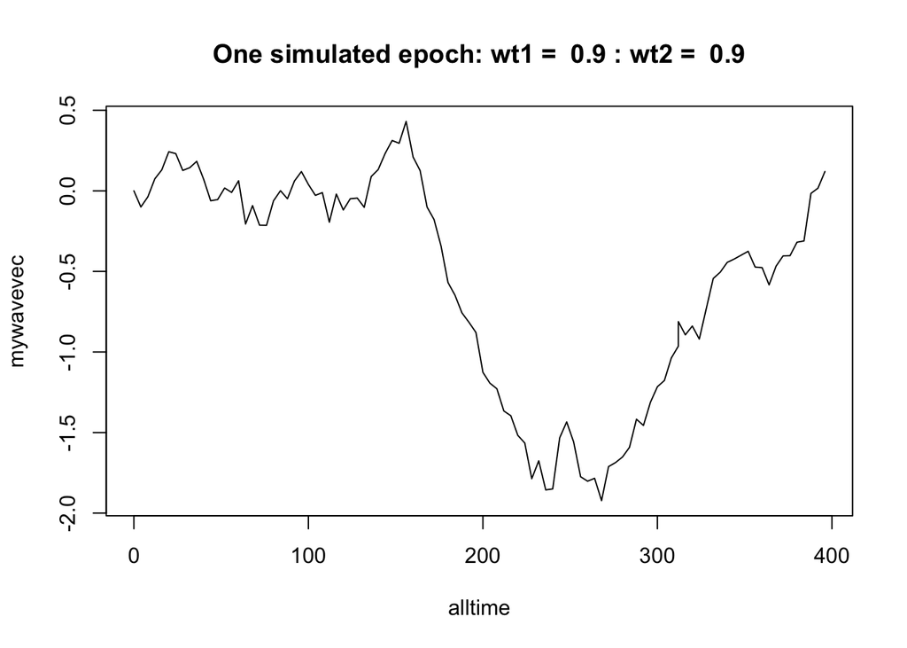

```r
wt1 <-.9 #specifies autocorrelation between pts - ie noisiness of waveform
wt2 <-.9 #specifies weighting for true effect - zero will give flat line
timepts <- length(alltime)
mywavevec <- mymakewave(timepts,wt1,wt2,truecurve)
plot(alltime,mywavevec,type='n', main=paste('One simulated epoch: wt1 = ',wt1,': wt2 = ',wt2))
lines(alltime,mywavevec)
```

We will now simulate data for a set of subjects; for each subject, we simulate a given number of trials and then take the average waveform.

```r
nsub<-16 #can alter this number, but it needs to be an even number


ntrials <- 30  #N trials to simulate: results saved in myresults for each run

#Next we initialise a dataframe to hold the averaged ERP for each subject: each row is one timepoint, and there's a column for each subject
subresults<-data.frame(matrix(NA,nrow=length(alltime),ncol=nsub+1))
subresults[,1]<-alltime #column 1 has the time values

#Another dataframe is initialised to store the MMN values for each subject
#We will compare how results vary depending on how this is computed: whether peak or average
allmmn<-data.frame(matrix(NA,nrow=nsub,ncol=3))

png("subs.png",width = 4, height = 4, units = 'in', res = 300)
#This plot too big for plot pane, so write to png: 4 x 4 grid of plots
par(mfrow=c(4,4), mai = c(.5, 0.1, 0.1, 0.1)) #mai sets margns to avoid big white spaces between plots

for (k in 1:nsub){
  plot(alltime,truecurve,type='n',ylim=c(-1,.6)) #just creates empty plot: we will add lines later

  myresults <- data.frame(matrix(NA,nrow=timepts,ncol=ntrials))#temporary store: overwritten for each subject

  wt1 <- .8 #weight that determines correlation between adjacent timepoints
  wt2 <- 0 #we start by simulating case where there is no true signal

  for (i in 1:ntrials){
    myresults[,i] <- mymakewave(timepts,wt1,wt2,truecurve)
    lines(alltime,myresults[,i],col='grey') #plot waveform for this trial: these all superimposed
  }

  #Now compute average across all trials
  mmnphase<-phase2r
  mmnavg<-rowMeans(myresults[,1:ntrials])
  subresults[,(k+1)] <-mmnavg #store the average waveform for this subject; time in row, mean amplitude in columns
  lines(alltime,mmnavg,col='blue') #add the average to plot for this subject
  thismmn<- min(mmnavg[mmnphase]) #find minimum value within the time window for MMN
  w<-which(mmnavg==thismmn) #find the corresponding index for this value
  abline(v=alltime[w],col='red') #draw vertical red line to show the peak value
  abline(v=alltime[w3],lty=2) #draw vertical dotted lines to show the window
  abline(v=alltime[w4],lty=2)
  allmmn[k,1]<-alltime[w] #record peak latency in col1 of allmmn
  allmmn[k,2]<-thismmn #record peak value in col2 of allmmn
  allmmn[k,3]<-mean(mmnavg[w3:w4]) #record mean amplitude in MMN window in col3  of allmmn
}
colnames(allmmn)<-c('Latency','Peak','Meanamp')
dev.off() #stop writing plots to png
```

Now look at values for MMN and test if they differ from zero.

```r
t.test(allmmn$Peak) #single sample t.test against mean of zero, peak amplitude
```

```
##
##  One Sample t-test
##
## data:  allmmn$Peak
## t = -12.724, df = 15, p-value = 1.934e-09
## alternative hypothesis: true mean is not equal to 0
## 95 percent confidence interval:
##  -0.13040013 -0.09298031
## sample estimates:
##  mean of x
## -0.1116902
```

```r
t.test(allmmn$Meanamp) #single sample t.test against mean of zero, mean amplitude
```

```
##
##  One Sample t-test
##
## data:  allmmn$Meanamp
## t = 0.085157, df = 15, p-value = 0.9333
## alternative hypothesis: true mean is not equal to 0
## 95 percent confidence interval:
##  -0.01269512  0.01375174
## sample estimates:
##    mean of x
## 0.0005283092
```

You should be able to see the impact of double-dipping: it makes a nonsense of the statistical test, because the data have been selected to be extreme. If you were to rely on this method to tell whether or not you had an MMN, you would be fooling yourself.

## Demonstration 2: electrode picking

In this demonstration, we will simulate data for 6 electrodes for each subject, and we will divide subjects into 2 groups. The aim is to show how statistics get distorted if you decide to base the analysis on the electrode that shows the biggest group difference: this will increase the odds of finding a false positive.

Within a subject, signals from different electrodes tend to be correlated; we will model this by simulating one function per subject, but then adding noise to this for each simulated electrode. For simplicity we will use values of truecurve etc as in demonstration 1, and we won’t simulate individual trials and then average them. (This means that to be realisitc we should simulate data that is not so noisy, as averaging over trials reduces noise).

```r
makemanywaves <- function(timepts,wt1,wt2,wt3,truecurve,nelec) {
  #wt3 is weight for additional random term: if this is low, then all waveforms will be similar
  mywavedf<-data.frame(matrix(0,nrow=timepts,ncol=nelec)) #initialise dataframe
  for (j in 2:timepts){
    electerm <-rnorm(1) #a random term for electrode: keep same for all electrodes for this subject
    #so we can generate correlated data
    for (e in 1:nelec){

      #work out next timepoint on basis of previous timepoint, randomness plus true curve
      mywavedf[j,e]<-wt1*mywavedf[j-1,e]+(1-wt1)*rnorm(1)+wt2*truecurve[j]+wt3*electerm
    }
  }
  return(mywavedf)

}
```

We plot data from 4 electrodes just to check whether the simulation is giving realistic data.

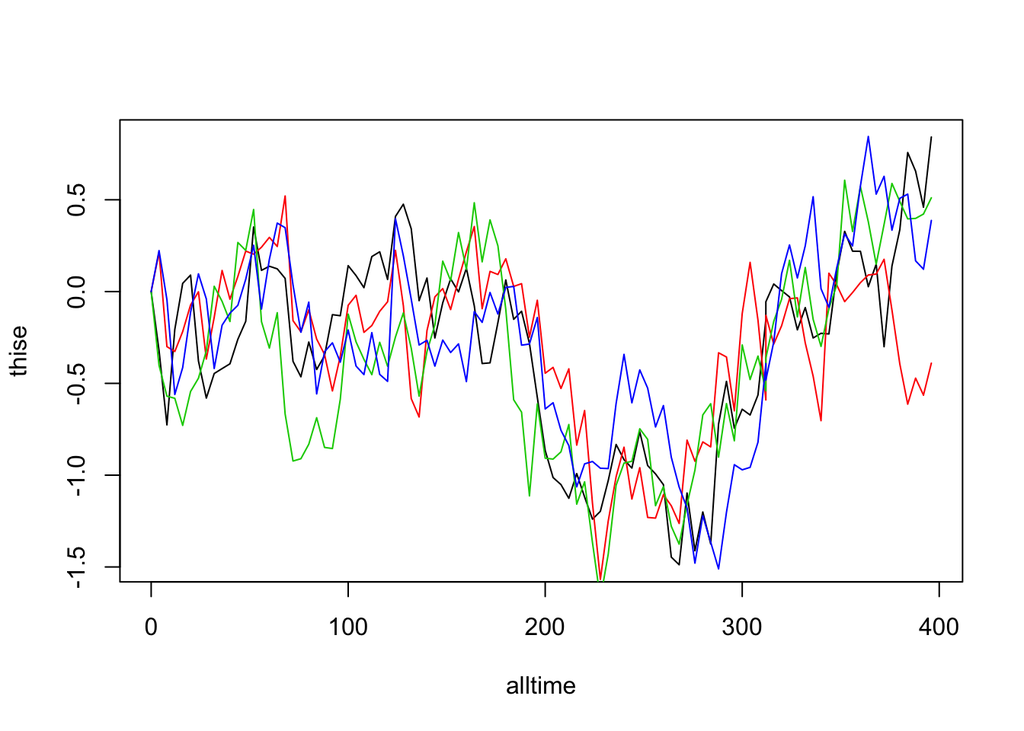

```r
wt1 <- .8
wt2 <- .8
wt3 <- .1
nelec=4

mywavedf <- makemanywaves(timepts,wt1,wt2,wt3,truecurve,nelec)
thise<-mywavedf[,1]
plot(alltime,thise,type='n')
for (e in 1:nelec){
  thise<-mywavedf[,e]
  lines(alltime,thise,col=e)
}
```

Now we will use this function to generate 6 electrode values for each of our subjects. Subjects, who don’t actually differ, will be subdivided into 2 groups and the grand average waveforms will be plotted. It we use p < .05 as a criterion for significance, we should not see a significant result on more than 1 in 20 runs of the simulation.

```r
#Specify the range of indices for group1 and group2, equal sized groups
subrange1<-1:(nsub/2)
subrange2<-(1+nsub/2):nsub

nelec=6

#Create a 3D array to hold data : time x subject x electrode
datamatrix <- array(0,dim=c(timepts,nsub,nelec))

#Populate the matrix - to simplify, rather than simulating individual trials and averaging, we will assume the simulated data is an averaged value. We'll specify a high value for wt1 and wt2, which will mean the waves include a true effect and are not so noisy.

wt1 <- .9 #term that influences noisiness of waveform
wt2 <- .4 #term that affects SNR - i.e. ability to detect true waveform influence
wt3 <- .1 #term that influences similarity between electrodes

for (k in 1:nsub){
  mywavedf <- makemanywaves(timepts,wt1,wt2,wt3,truecurve,nelec)
  datamatrix[,k,]<-as.matrix(mywavedf)
}
```

Next we will compute the average in the MMN window for each subject at each electrode

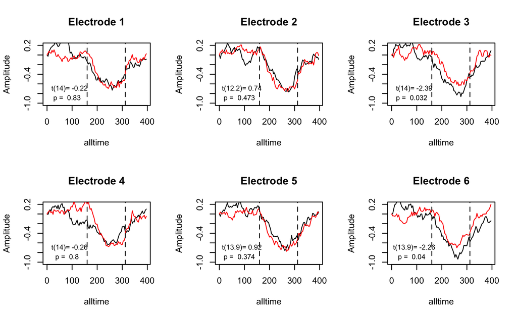

Simulated electrodes

```r
elecdf <- data.frame(matrix(0,nrow=nsub,ncol=nelec))
for (k in 1:nsub){
  for (e in 1:nelec){
    elecdf[k,e]<-mean(datamatrix[mmnphase,k,e])
  }
}

#now inspect waveforms for group1 and group2 for each electrode
png("elecplots.png", width = 6.5, height = 4, units = 'in', res = 300) #write plot to png file

par(mfrow=c(2,3)) #plots in a 2 x 3 grid
elecdf$group <-1
elecdf$group[subrange2]<-2

 for (e in 1:nelec){
   plot(alltime,rowMeans(datamatrix[,subrange1,e]),type='l',main=paste('Electrode',e),
        ylim=c(-1,.2),ylab='Amplitude')
   lines(alltime,rowMeans(datamatrix[,subrange2,e]),col=2)
    myt<- t.test(elecdf[,e]~elecdf$group)
   text(90,-.7,paste0('t(',round(myt$parameter,1),')= ',round(myt$statistic,2)),cex=.8)
   text(80,-.9,paste('p = ',round(myt$p.value,3)),cex=.8)
   abline(v=alltime[mmnphase[1]],lty=2)
   abline(v=alltime[max(mmnphase)],lty=2)
 }

dev.off()
```

The two groups - which are entirely arbitrarily assigned - correspond to the black and red lines.

You can see that even with weights specified to give relatively clean data, there is variation from electrode to electrode in the group difference.

The more electrodes that are simulated, the higher the probability that at least one electrode will show a ‘significant’ group difference. The proportion of ‘significant’ effects will depend on the extent to which the electrode values are intercorrelated.

You will get different results each time you run the simulation; with current settings at least one electrode shows a ‘signficant’ (i.e. p < .05) group difference on about 25% of trials.